# Prediction of Wine quality

### Mayouran VARATHALINGAM

## Prediction of wine quality based on its composition

```python
import pandas as pd
import numpy as np
from matplotlib.colors import LinearSegmentedColormap
import matplotlib.pyplot as plt
import seaborn as sns
from IPython.display import Markdown as md
from sklearn.preprocessing import StandardScaler
from sklearn import linear_model
from sklearn.model_selection import train_test_split
from sklearn.metrics import *
from sklearn.neighbors import KNeighborsClassifier
from sklearn.tree import DecisionTreeClassifier
from sklearn.svm import SVC
from sklearn.ensemble import RandomForestClassifier
from sklearn.model_selection import GridSearchCV
from sklearn.ensemble import VotingClassifier
```

## 1. Analysis of the dataset:

```python
dfWine = pd.read_csv("winequality-white.csv", sep=";")
```

```python
dfWine.head()
```

|  | fixed acidity | volatile acidity | citric acid | residual sugar | chlorides | free sulfur dioxide | total sulfur dioxide | density | pH | sulphates | alcohol | quality |
| --- | --- | --- | --- | --- | --- | --- | --- | --- | --- | --- | --- | --- |
| 0 | 7.0 | 0.27 | 0.36 | 20.7 | 0.045 | 45.0 | 170.0 | 1.0010 | 3.00 | 0.45 | 8.8 | 6 |
| 1 | 6.3 | 0.30 | 0.34 | 1.6 | 0.049 | 14.0 | 132.0 | 0.9940 | 3.30 | 0.49 | 9.5 | 6 |
| 2 | 8.1 | 0.28 | 0.40 | 6.9 | 0.050 | 30.0 | 97.0 | 0.9951 | 3.26 | 0.44 | 10.1 | 6 |
| 3 | 7.2 | 0.23 | 0.32 | 8.5 | 0.058 | 47.0 | 186.0 | 0.9956 | 3.19 | 0.40 | 9.9 | 6 |
| 4 | 7.2 | 0.23 | 0.32 | 8.5 | 0.058 | 47.0 | 186.0 | 0.9956 | 3.19 | 0.40 | 9.9 | 6 |

```python
dfWine.info()
```

```
<class 'pandas.core.frame.DataFrame'>
RangeIndex: 4898 entries, 0 to 4897
Data columns (total 12 columns):
fixed acidity           4898 non-null float64
volatile acidity        4898 non-null float64
citric acid             4898 non-null float64
residual sugar          4898 non-null float64
chlorides               4898 non-null float64
free sulfur dioxide     4898 non-null float64
total sulfur dioxide    4898 non-null float64
density                 4898 non-null float64
pH                      4898 non-null float64
sulphates               4898 non-null float64
alcohol                 4898 non-null float64
quality                 4898 non-null int64
dtypes: float64(11), int64(1)
memory usage: 459.3 KB
```

We can see that there are not any **null values** and **all the datatypes** seem **correct.**

```python
dfWine.describe()
```

|  | fixed acidity | volatile acidity | citric acid | residual sugar | chlorides | free sulfur dioxide | total sulfur dioxide | density | pH | sulphates | alcohol | quality |
| --- | --- | --- | --- | --- | --- | --- | --- | --- | --- | --- | --- | --- |
| count | 4898.000000 | 4898.000000 | 4898.000000 | 4898.000000 | 4898.000000 | 4898.000000 | 4898.000000 | 4898.000000 | 4898.000000 | 4898.000000 | 4898.000000 | 4898.000000 |
| mean | 6.854788 | 0.278241 | 0.334192 | 6.391415 | 0.045772 | 35.308085 | 138.360657 | 0.994027 | 3.188267 | 0.489847 | 10.514267 | 5.877909 |
| std | 0.843868 | 0.100795 | 0.121020 | 5.072058 | 0.021848 | 17.007137 | 42.498065 | 0.002991 | 0.151001 | 0.114126 | 1.230621 | 0.885639 |
| min | 3.800000 | 0.080000 | 0.000000 | 0.600000 | 0.009000 | 2.000000 | 9.000000 | 0.987110 | 2.720000 | 0.220000 | 8.000000 | 3.000000 |
| 25% | 6.300000 | 0.210000 | 0.270000 | 1.700000 | 0.036000 | 23.000000 | 108.000000 | 0.991723 | 3.090000 | 0.410000 | 9.500000 | 5.000000 |
| 50% | 6.800000 | 0.260000 | 0.320000 | 5.200000 | 0.043000 | 34.000000 | 134.000000 | 0.993740 | 3.180000 | 0.470000 | 10.400000 | 6.000000 |
| 75% | 7.300000 | 0.320000 | 0.390000 | 9.900000 | 0.050000 | 46.000000 | 167.000000 | 0.996100 | 3.280000 | 0.550000 | 11.400000 | 6.000000 |
| max | 14.200000 | 1.100000 | 1.660000 | 65.800000 | 0.346000 | 289.000000 | 440.000000 | 1.038980 | 3.820000 | 1.080000 | 14.200000 | 9.000000 |

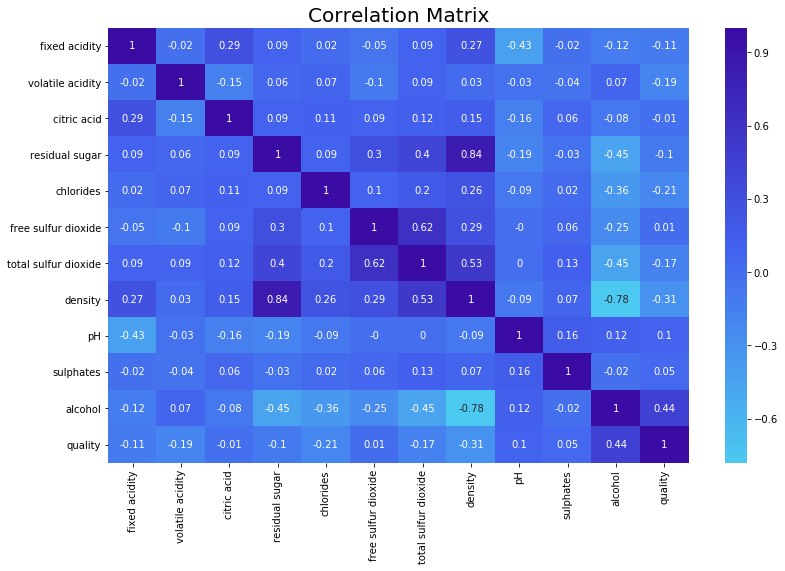

```python
cmap = LinearSegmentedColormap.from_list('mycmap', ['#4cc9f0','#4361ee','#3a0ca3'])

plt.figure(figsize=(13,8))
ax = sns.heatmap(dfWine.corr().round(decimals=2), cmap=cmap, annot=True)
plt.title("Correlation Matrix", fontsize=20)
plt.show()
```

The feature **alcohol** seems to have a higher correlation with the wine **quality**, with a correlation of **0.44**.

Our goal here is to predict the quality of a wine based on its composition. So in our dataset, the **target variable** will be **"quality"**.

```python
columns = ['fixed acidity', 'volatile acidity', 'citric acid', 'residual sugar', 'chlorides', 'free sulfur dioxide', 'total sulfur dioxide', 'density', 'pH', 'sulphates', 'alcohol']
features = dfWine[columns]
target = dfWine['quality']
```

```python
scaler = StandardScaler()
scaler.fit(features)
scaled_features = scaler.transform(features)
```

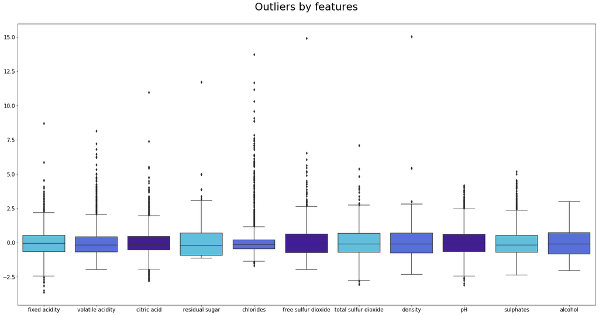

```python
colorPalette = ['#4cc9f0','#4361ee','#3a0ca3']
fig = plt.figure(figsize=(30,15))
sns.boxplot(data=scaled_features, palette=colorPalette)
# plt.axes().set_xticklabels(['fixed acidity', 'volatile acidity', 'citric acid', 'residual sugar', 'chlorides', 'free sulfur dioxide', 'total sulfur dioxide', 'density', 'pH', 'sulphates', 'alcohol'], fontsize=13)
plt.xticks(np.arange(11),['fixed acidity', 'volatile acidity', 'citric acid', 'residual sugar', 'chlorides', 'free sulfur dioxide', 'total sulfur dioxide', 'density', 'pH', 'sulphates', 'alcohol'], fontsize=15)
plt.yticks(fontsize=15)
plt.title("Outliers by features\n",fontsize=30)
```

```python
df_scaled_features = pd.DataFrame(scaled_features)
df_scaled_features.columns= ['fixed acidity', 'volatile acidity', 'citric acid', 'residual sugar', 'chlorides', 'free sulfur dioxide', 'total sulfur dioxide', 'density', 'pH', 'sulphates', 'alcohol']
df_scaled_features.head()
```

|  | fixed acidity | volatile acidity | citric acid | residual sugar | chlorides | free sulfur dioxide | total sulfur dioxide | density | pH | sulphates | alcohol |
| --- | --- | --- | --- | --- | --- | --- | --- | --- | --- | --- | --- |
| 0 | 0.172097 | -0.081770 | 0.213280 | 2.821349 | -0.035355 | 0.569932 | 0.744565 | 2.331512 | -1.246921 | -0.349184 | -1.393152 |
| 1 | -0.657501 | 0.215896 | 0.048001 | -0.944765 | 0.147747 | -1.253019 | -0.149685 | -0.009154 | 0.740029 | 0.001342 | -0.824276 |
| 2 | 1.475751 | 0.017452 | 0.543838 | 0.100282 | 0.193523 | -0.312141 | -0.973336 | 0.358665 | 0.475102 | -0.436816 | -0.336667 |
| 3 | 0.409125 | -0.478657 | -0.117278 | 0.415768 | 0.559727 | 0.687541 | 1.121091 | 0.525855 | 0.011480 | -0.787342 | -0.499203 |
| 4 | 0.409125 | -0.478657 | -0.117278 | 0.415768 | 0.559727 | 0.687541 | 1.121091 | 0.525855 | 0.011480 | -0.787342 | -0.499203 |

```python
for i in df_scaled_features.columns:
    for j in df_scaled_features[i]:
        q1 = df_scaled_features[i].quantile(0.25)
        q3 = df_scaled_features[i].quantile(0.75)
        iqr = q3-q1
        Lower_tail = q1 - 1.5 * iqr
        Upper_tail = q3 + 1.5 * iqr
        if j > Upper_tail or j < Lower_tail:
            df_scaled_features[i] = df_scaled_features[i].replace(j, np.mean(df_scaled_features[i]))
```

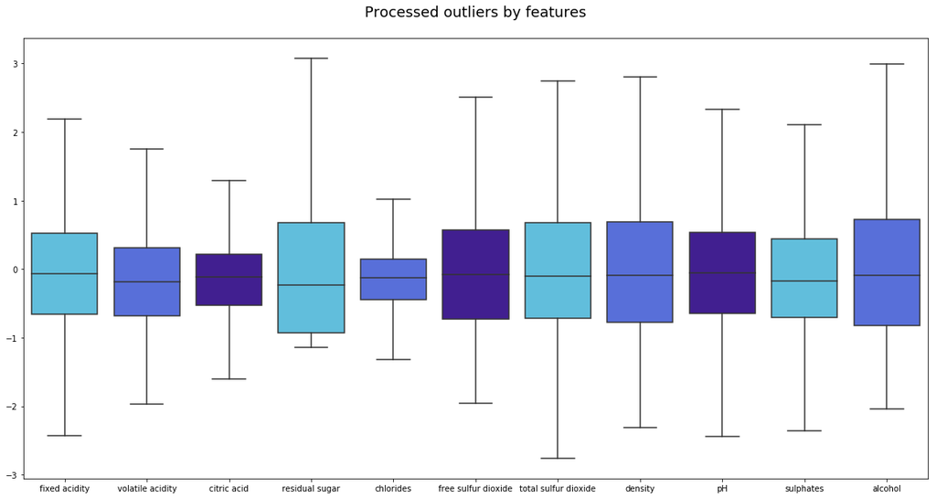

```python
fig = plt.figure(figsize=(20,10))
sns.boxplot(data=df_scaled_features, palette=colorPalette)
plt.title("Processed outliers by features\n",fontsize=18)
```

We can see that we don't have **outlier** anymore.

## 2. Machine Learning and Prediction:

### a. Regression

### Linear Regression

```python
#We will do the regression only with the feature alcohol
alcohol = df_scaled_features.iloc[:,10].values.reshape((len(target),1))
targetReg = target.values.reshape((len(target),1))
print(alcohol.shape)
print(targetReg.shape)
```

```
(4898, 1)
(4898, 1)
```

```python
X_train,X_test,y_train,y_test = train_test_split(alcohol, targetReg, test_size=0.2, random_state=0)

print(X_train)
```

```
[[-0.01159456]
 [ 1.53249956]
 [ 0.80108656]
 ...
 [-1.39315246]
 [ 0.23220977]
 [-0.41793512]]
```

```python
lin_regr = linear_model.LinearRegression()
lin_regr.fit(X_train, y_train)
```

```
LinearRegression()
```

```python
predicted_y = lin_regr.predict(X_test)
```

```python
md(f"Mean squared error: **<font color=#3a0ca3>{mean_squared_error(y_test,predicted_y):.2f}</font>**")
```

Mean squared error: **0.73**

```python
md(f"Root mean squared error: **<font color=#3a0ca3>{mean_squared_error(y_test,predicted_y, squared=False):.2f}</font>**")
```

Root mean squared error: **0.85**

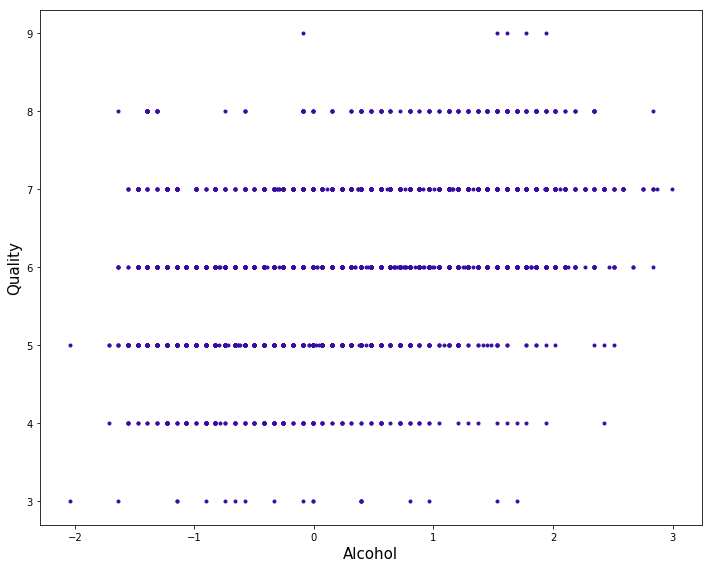

```python
fig = plt.figure(figsize=(10,8))
plt.plot(alcohol, targetReg, "b.", color = "#3a0ca3")
plt.xlabel("Alcohol", fontsize=15)
plt.ylabel("Quality", fontsize=15)
plt.tight_layout()
```

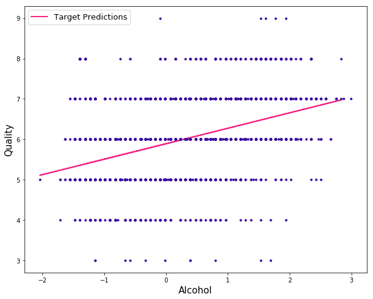

```python
fig = plt.figure(figsize=(10,8))
plt.plot(X_test,predicted_y, "r-", linewidth=2, label="Target Predictions", color="#f72585")
plt.plot( X_train,y_train, "b.", color="#3a0ca3")
plt.xlabel("Alcohol", fontsize=15)
plt.ylabel("Quality", fontsize=15)
plt.legend(loc="upper left", fontsize=13)
plt.show()
```

```python
df_linear_regr = pd.DataFrame({'Actual': y_test.flatten(), 'Predicted': predicted_y.flatten()})
df_linear_regr.head(5)
```

|  | Actual | Predicted |
| --- | --- | --- |
| 0 | 5 | 5.948460 |
| 1 | 6 | 5.668554 |
| 2 | 7 | 5.979560 |
| 3 | 8 | 6.632673 |
| 4 | 5 | 5.761856 |

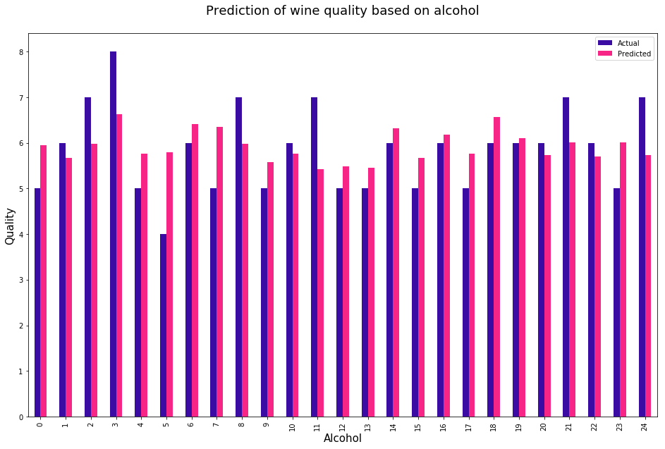

```python
df_linear_regr_bar = df_linear_regr.head(25)
df_linear_regr_bar.plot(kind='bar',color = ['#3a0ca3', '#f72585'], figsize=(16,10))
plt.title("Prediction of wine quality based on alcohol\n",fontsize=18)
plt.xlabel("Alcohol", fontsize=15)
plt.ylabel("Quality", fontsize=15)
```

### Logistic regression

```python
X_train,X_test,y_train,y_test = train_test_split(scaled_features, targetReg, test_size=0.2, random_state=0)
```

```python
log_reg = linear_model.LogisticRegression(solver ='newton-cg', multi_class='multinomial',max_iter=1000)
log_reg.fit(X_train,y_train.ravel())
```

```
LogisticRegression(max_iter=1000, multi_class='multinomial', solver='newton-cg')
```

```python
y_hat = log_reg.predict(X_test)
```

```python
acc = accuracy_score(y_hat,y_test)
md(f"Accuracy: **<font color=#3a0ca3>{100*acc:.2f}%</font>**")
```

Accuracy: **51.22%**

```python
md(f"Mean squared error: **<font color=#3a0ca3>{mean_squared_error(y_test,y_hat):.2f}</font>**")
```

Mean squared error: **0.73**

```python
md(f"Root mean squared error: **<font color=#3a0ca3>{mean_squared_error(y_test,y_hat, squared=False):.2f}</font>**")
```

Root mean squared error: **0.85**

```python
df_logist_regr = pd.DataFrame({'Actual': y_test.flatten(), 'Predicted': y_hat.flatten()})
df_logist_regr.head(5)
```

|  | Actual | Predicted |
| --- | --- | --- |
| 0 | 5 | 5 |
| 1 | 6 | 5 |
| 2 | 7 | 6 |
| 3 | 8 | 7 |
| 4 | 5 | 6 |

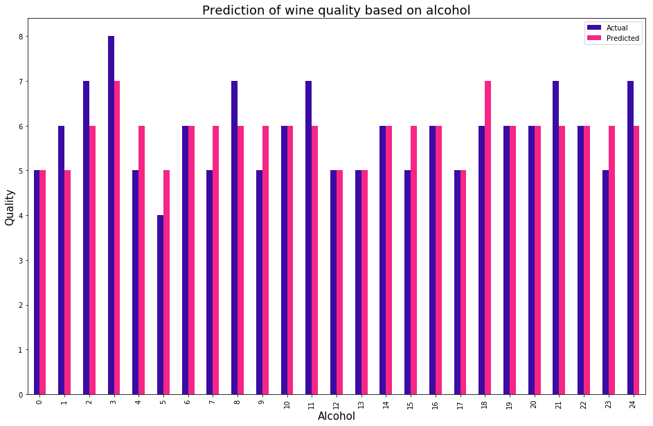

```python
df_logist_regr_bar = df_logist_regr.head(25)
df_logist_regr_bar.plot(kind='bar',color = ['#3a0ca3', '#f72585'], figsize=(16,10))
plt.title("Prediction of wine quality based on alcohol",fontsize=18)
plt.xlabel("Alcohol", fontsize=15)
plt.ylabel("Quality", fontsize=15)
```

### b. Classification

### KNN

```python
X_trainKnn,X_testKnn,y_trainKnn,y_testKnn = train_test_split(df_scaled_features, targetReg, test_size=0.2, random_state=0)
```

```python
Knn = KNeighborsClassifier (n_neighbors=10,p=1)
Knn.fit(X_trainKnn,y_trainKnn.ravel())
```

```
KNeighborsClassifier(n_neighbors=10, p=1)
```

```python
y_pred_knn=Knn.predict(X_testKnn)
```

```python
print("Wrong values predicted out of total values : ")
print((y_testKnn!=y_pred_knn).sum(),'/',((y_testKnn==y_pred_knn).sum()+(y_testKnn!=y_pred_knn).sum()))
```

```
Wrong values predicted out of total values :
630176 / 960400
```

```python
md(f"Accuracy using **<font color=#3a0ca3>KNN</font>** is: **<font color=#3a0ca3>{100*accuracy_score(y_testKnn,y_pred_knn):.2f}%</font>**")
```

Accuracy using **KNN** is: **51.02%**

```python
adjusted_rand_score(y_testKnn.ravel(), y_pred_knn)
```

```
0.09186932267667855
```

```python
dfKnn = pd.DataFrame(X_testKnn)
```

```python
dfKnn.columns = ['fixed acidity', 'volatile acidity', 'citric acid', 'residual sugar', 'chlorides', 'free sulfur dioxide', 'total sulfur dioxide', 'density', 'pH', 'sulphates', 'alcohol']
```

```python
dfKnn['True'] = y_testKnn
dfKnn['Predict'] = y_pred_knn
dfKnn.reset_index(inplace = True, drop = True)
```

```python
dfKnn.head()
```

|  | fixed acidity | volatile acidity | citric acid | residual sugar | chlorides | free sulfur dioxide | total sulfur dioxide | density | pH | sulphates | alcohol | True | Predict |
| --- | --- | --- | --- | --- | --- | --- | --- | --- | --- | --- | --- | --- | --- |
| 0 | 0.527639 | 0.414339 | 0.130641 | -0.984201 | 0.193523 | -1.605848 | 0.579835 | -0.530788 | 0.342639 | -0.612079 | 0.150942 | 5 | 5 |
| 1 | 0.172097 | 0.315117 | -0.613115 | 0.198872 | -0.080834 | -0.429751 | 0.509236 | 0.458979 | -0.385910 | -0.261553 | -0.580471 | 6 | 5 |
| 2 | 0.883181 | -1.371654 | -0.046493 | -0.944765 | -0.264233 | -0.488556 | -0.832138 | -0.811668 | -0.783300 | -0.787342 | 0.232210 | 7 | 6 |
| 3 | -2.198183 | 0.116674 | -0.030487 | -0.136332 | -0.493110 | 1.099175 | 0.391572 | -1.426929 | 0.541334 | -1.313131 | 1.938840 | 8 | 6 |
| 4 | -1.013043 | 0.017452 | -0.943673 | 1.135471 | 0.101972 | 0.393517 | 0.579835 | 0.559293 | 0.077712 | -0.261553 | -0.336667 | 5 | 5 |

```python
dfKnn['True'] = pd.Categorical(dfKnn['True'])
dfKnn['Predict'] = pd.Categorical(dfKnn['Predict'])
```

```python
dfKnn.info()
```

```
<class 'pandas.core.frame.DataFrame'>
RangeIndex: 980 entries, 0 to 979
Data columns (total 13 columns):
fixed acidity           980 non-null float64
volatile acidity        980 non-null float64
citric acid             980 non-null float64
residual sugar          980 non-null float64
chlorides               980 non-null float64
free sulfur dioxide     980 non-null float64
total sulfur dioxide    980 non-null float64
density                 980 non-null float64
pH                      980 non-null float64
sulphates               980 non-null float64
alcohol                 980 non-null float64
True                    980 non-null category
Predict                 980 non-null category
dtypes: category(2), float64(11)
memory usage: 86.6 KB
```

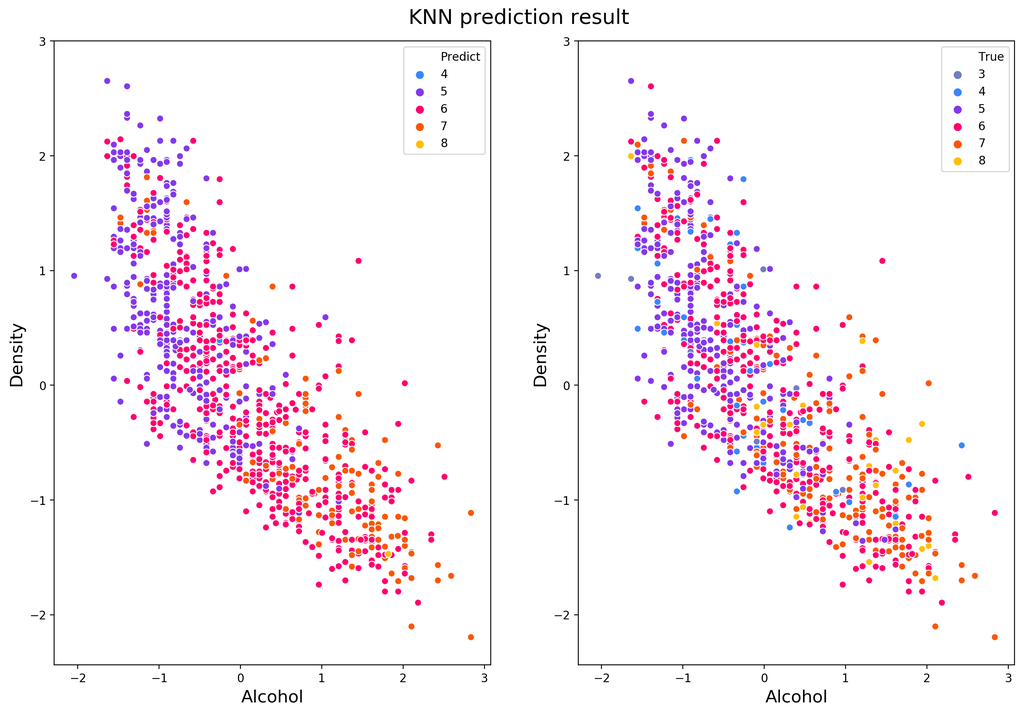

```python
paletteScatter = {3:'#717EC3', 4:'#3A86FF', 5:'#8338EC', 6:'#FF006E', 7:'#FB5607', 8:'#FFBE0B'}
fig = plt.figure(figsize=(15,10), dpi=200)
plt.suptitle("KNN prediction result",fontsize=18, y=0.92)
plt.subplot(121)
sns.scatterplot(data=dfKnn, x=dfKnn['alcohol'], y=dfKnn['density'], hue=dfKnn['Predict'], palette=paletteScatter)
plt.ylim(ymax=3.0)
plt.xlabel("Alcohol",fontsize=15)
plt.ylabel("Density",fontsize=15)
plt.subplot(122)
sns.scatterplot(data=dfKnn, x=dfKnn['alcohol'], y=dfKnn['density'], hue=dfKnn['True'], palette=paletteScatter)
plt.ylim(ymax=3.0)
plt.xlabel("Alcohol",fontsize=15)
plt.ylabel("Density",fontsize=15)
```

### Decision Tree

```python
X_trainDT,X_testDT,y_trainDT,y_testDT = train_test_split(df_scaled_features, targetReg, test_size=0.2, random_state=0)
```

```python
tree = DecisionTreeClassifier(max_depth=4,random_state=0)
tree.fit(X_trainDT, y_trainDT.ravel())
```

```
DecisionTreeClassifier(max_depth=4, random_state=0)
```

```python
y_pred_dt = tree.predict(X_testDT)
```

```python
print(classification_report(y_testDT, y_pred_dt.round(), digits=3))
```

```
              precision    recall  f1-score   support

           3      0.000     0.000     0.000         9
           4      0.000     0.000     0.000        51
           5      0.535     0.522     0.528       295
           6      0.480     0.638     0.548       409
           7      0.392     0.317     0.350       183
           8      0.000     0.000     0.000        33

    accuracy                          0.483       980
   macro avg      0.234     0.246     0.238       980
weighted avg      0.434     0.483     0.453       980
```

```python
print("Wrong values predicted out of total values : ")
print((y_testDT!=y_pred_dt).sum(),'/',((y_testDT==y_pred_dt).sum()+(y_testDT!=y_pred_dt).sum()))
```

```
Wrong values predicted out of total values :
625860 / 960400
```

```python
md(f"Accuracy using **<font color=#3a0ca3>Decision Tree</font>** is: **<font color=#3a0ca3>{100*accuracy_score(y_testDT,y_pred_dt):.2f}%</font>**")
```

Accuracy using **Decision Tree** is: **48.27%**

```python
adjusted_rand_score(y_testDT.ravel(), y_pred_dt)
```

```
0.07016693981479545
```

```python
dfTree = pd.DataFrame(X_testDT)
dfTree.columns = ['fixed acidity', 'volatile acidity', 'citric acid', 'residual sugar', 'chlorides', 'free sulfur dioxide', 'total sulfur dioxide', 'density', 'pH', 'sulphates', 'alcohol']
dfTree['True'] = y_testDT
dfTree['Predict'] = y_pred_dt
dfTree.head()
```

|  | fixed acidity | volatile acidity | citric acid | residual sugar | chlorides | free sulfur dioxide | total sulfur dioxide | density | pH | sulphates | alcohol | True | Predict |
| --- | --- | --- | --- | --- | --- | --- | --- | --- | --- | --- | --- | --- | --- |
| 2762 | 0.527639 | 0.414339 | 0.130641 | -0.984201 | 0.193523 | -1.605848 | 0.579835 | -0.530788 | 0.342639 | -0.612079 | 0.150942 | 5 | 5 |
| 42 | 0.172097 | 0.315117 | -0.613115 | 0.198872 | -0.080834 | -0.429751 | 0.509236 | 0.458979 | -0.385910 | -0.261553 | -0.580471 | 6 | 5 |
| 1419 | 0.883181 | -1.371654 | -0.046493 | -0.944765 | -0.264233 | -0.488556 | -0.832138 | -0.811668 | -0.783300 | -0.787342 | 0.232210 | 7 | 6 |
| 3664 | -2.198183 | 0.116674 | -0.030487 | -0.136332 | -0.493110 | 1.099175 | 0.391572 | -1.426929 | 0.541334 | -1.313131 | 1.938840 | 8 | 7 |
| 2125 | -1.013043 | 0.017452 | -0.943673 | 1.135471 | 0.101972 | 0.393517 | 0.579835 | 0.559293 | 0.077712 | -0.261553 | -0.336667 | 5 | 6 |

```python
dfTree.reset_index(inplace = True, drop = True)
```

```python
dfTree.head()
```

|  | fixed acidity | volatile acidity | citric acid | residual sugar | chlorides | free sulfur dioxide | total sulfur dioxide | density | pH | sulphates | alcohol | True | Predict |
| --- | --- | --- | --- | --- | --- | --- | --- | --- | --- | --- | --- | --- | --- |
| 0 | 0.527639 | 0.414339 | 0.130641 | -0.984201 | 0.193523 | -1.605848 | 0.579835 | -0.530788 | 0.342639 | -0.612079 | 0.150942 | 5 | 5 |
| 1 | 0.172097 | 0.315117 | -0.613115 | 0.198872 | -0.080834 | -0.429751 | 0.509236 | 0.458979 | -0.385910 | -0.261553 | -0.580471 | 6 | 5 |
| 2 | 0.883181 | -1.371654 | -0.046493 | -0.944765 | -0.264233 | -0.488556 | -0.832138 | -0.811668 | -0.783300 | -0.787342 | 0.232210 | 7 | 6 |
| 3 | -2.198183 | 0.116674 | -0.030487 | -0.136332 | -0.493110 | 1.099175 | 0.391572 | -1.426929 | 0.541334 | -1.313131 | 1.938840 | 8 | 7 |
| 4 | -1.013043 | 0.017452 | -0.943673 | 1.135471 | 0.101972 | 0.393517 | 0.579835 | 0.559293 | 0.077712 | -0.261553 | -0.336667 | 5 | 6 |

```python
dfTree['True'] = pd.Categorical(dfTree['True'])
dfTree['Predict'] = pd.Categorical(dfTree['Predict'])
dfTree.info()
```

```
<class 'pandas.core.frame.DataFrame'>
RangeIndex: 980 entries, 0 to 979
Data columns (total 13 columns):
fixed acidity           980 non-null float64
volatile acidity        980 non-null float64
citric acid             980 non-null float64
residual sugar          980 non-null float64
chlorides               980 non-null float64
free sulfur dioxide     980 non-null float64
total sulfur dioxide    980 non-null float64
density                 980 non-null float64
pH                      980 non-null float64
sulphates               980 non-null float64
alcohol                 980 non-null float64
True                    980 non-null category
Predict                 980 non-null category
dtypes: category(2), float64(11)
memory usage: 86.5 KB
```

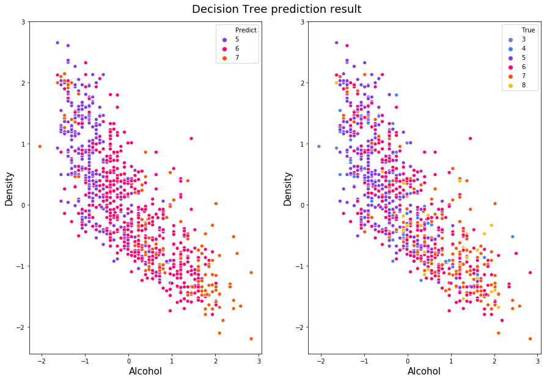

```python
paletteScatter = {3:'#717EC3', 4:'#3A86FF', 5:'#8338EC', 6:'#FF006E', 7:'#FB5607', 8:'#FFBE0B'}
fig = plt.figure(figsize=(15,10))
plt.suptitle("Decision Tree prediction result",fontsize=18, y=0.92)
plt.subplot(121)
sns.scatterplot(data=dfTree, x=dfTree['alcohol'], y=dfTree['density'], hue=dfTree['Predict'], palette=paletteScatter)
plt.ylim(ymax=3.0)
plt.xlabel("Alcohol",fontsize=15)
plt.ylabel("Density",fontsize=15)
plt.subplot(122)
sns.scatterplot(data=dfTree, x=dfTree['alcohol'], y=dfTree['density'], hue=dfTree['True'], palette=paletteScatter)
plt.ylim(ymax=3.0)
plt.xlabel("Alcohol",fontsize=15)
plt.ylabel("Density",fontsize=15)
```

### SVC

```python
X_trainSvc,X_testSvc,y_trainSvc,y_testSvc = train_test_split(df_scaled_features, targetReg, test_size=0.2, random_state=0)
```

```python
svc_model = SVC()
svc_model.fit(X_train, y_train.ravel())

y_pred_svc = svc_model.predict(X_testSvc)
```

```python
md(f"Accuracy using **<font color=#3a0ca3>SVC</font>** is: **<font color=#3a0ca3>{100*accuracy_score(y_testSvc,y_pred_svc):.2f}%</font>**")
```

Accuracy using **SVC** is: **53.47%**

```python
print(adjusted_rand_score(y_testSvc.ravel(), y_pred_svc))
```

```
0.1133982159886251
```

```python
dfSvc = pd.DataFrame(X_testSvc)
dfSvc.columns = ['fixed acidity', 'volatile acidity', 'citric acid', 'residual sugar', 'chlorides', 'free sulfur dioxide', 'total sulfur dioxide', 'density', 'pH', 'sulphates', 'alcohol']
```

```python
dfSvc['True'] = y_testSvc
dfSvc['Predict'] = y_pred_svc
dfSvc.reset_index(inplace = True, drop = True)
dfSvc.head()
```

|  | fixed acidity | volatile acidity | citric acid | residual sugar | chlorides | free sulfur dioxide | total sulfur dioxide | density | pH | sulphates | alcohol | True | Predict |
| --- | --- | --- | --- | --- | --- | --- | --- | --- | --- | --- | --- | --- | --- |
| 0 | 0.527639 | 0.414339 | 0.130641 | -0.984201 | 0.193523 | -1.605848 | 0.579835 | -0.530788 | 0.342639 | -0.612079 | 0.150942 | 5 | 5 |
| 1 | 0.172097 | 0.315117 | -0.613115 | 0.198872 | -0.080834 | -0.429751 | 0.509236 | 0.458979 | -0.385910 | -0.261553 | -0.580471 | 6 | 5 |
| 2 | 0.883181 | -1.371654 | -0.046493 | -0.944765 | -0.264233 | -0.488556 | -0.832138 | -0.811668 | -0.783300 | -0.787342 | 0.232210 | 7 | 6 |
| 3 | -2.198183 | 0.116674 | -0.030487 | -0.136332 | -0.493110 | 1.099175 | 0.391572 | -1.426929 | 0.541334 | -1.313131 | 1.938840 | 8 | 7 |
| 4 | -1.013043 | 0.017452 | -0.943673 | 1.135471 | 0.101972 | 0.393517 | 0.579835 | 0.559293 | 0.077712 | -0.261553 | -0.336667 | 5 | 6 |

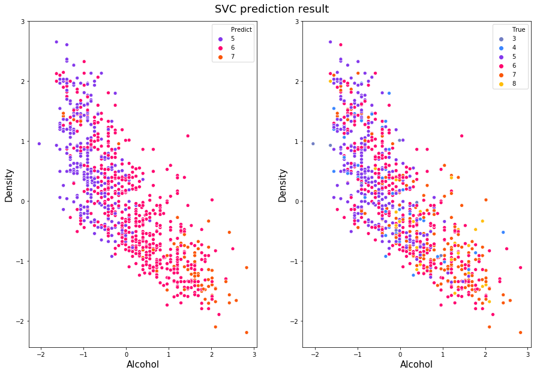

```python
fig = plt.figure(figsize=(15,10))
plt.suptitle("SVC prediction result",fontsize=18, y=0.92)
plt.subplot(121)
sns.scatterplot(data=dfSvc, x=dfSvc['alcohol'], y=dfSvc['density'], hue=dfSvc['Predict'], palette=paletteScatter)
plt.ylim(ymax=3.0)
plt.xlabel("Alcohol",fontsize=15)
plt.ylabel("Density",fontsize=15)
plt.subplot(122)
sns.scatterplot(data=dfSvc, x=dfSvc['alcohol'], y=dfSvc['density'], hue=dfSvc['True'], palette=paletteScatter)
plt.ylim(ymax=3.0)
plt.xlabel("Alcohol",fontsize=15)
plt.ylabel("Density",fontsize=15)
```

```python
knnAccuracy = round(100*accuracy_score(y_testKnn,y_pred_knn),2)
dtAccuracy = round(100*accuracy_score(y_testDT,y_pred_dt),2)
svcAccuracy = round(100*accuracy_score(y_testSvc,y_pred_svc),2)
```

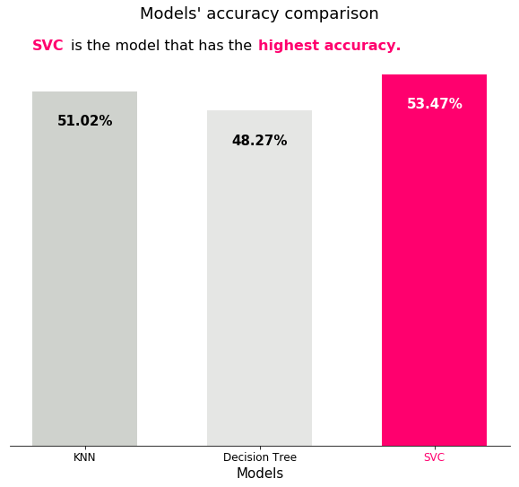

```python
fig = plt.figure(figsize=(10,8))
plt.bar(x=['KNN','Decision Tree', 'SVC'], height=[knnAccuracy,dtAccuracy,svcAccuracy],
        width=0.6,
        color=['#cfd2cd','#e5e6e4','#FF006E'])
plt.text(0,knnAccuracy-5,f'{knnAccuracy}%',ha='center',fontsize=15, fontweight='bold')
plt.text(1,dtAccuracy-5,f'{dtAccuracy}%',ha='center',fontsize=15, fontweight='bold')
plt.text(2,svcAccuracy-5,f'{svcAccuracy}%',ha='center',fontsize=15, fontweight='bold', color='white')
plt.text(0.16,0.89,'SVC',transform=fig.transFigure, fontsize=16, fontweight='bold', color='#FF006E')
plt.text(0.22,0.89,'is the model that has the',transform=fig.transFigure, fontsize=16)
plt.text(0.51,0.89,'highest accuracy.',transform=fig.transFigure, fontsize=16, fontweight='bold', color='#FF006E')
plt.xticks(fontsize=12)
plt.yticks([])
plt.title("Models' accuracy comparison", fontsize=18, y=1.08)
plt.xlabel('Models',fontsize=15)
plt.gca().get_xticklabels()[2].set_color('#FF006E')
sns.despine(left=True)
```

### c. Optimisation

### KNN

```python
knn = KNeighborsClassifier()
param_grid = {"n_neighbors": np.arange(1, 32),
              "weights":['uniform','distance'],
              "metric":['minkowski','euclidean','manhattan']
             }
knn_gscv = GridSearchCV(knn, param_grid, cv=5)
knn_gscv.fit(X_trainKnn, y_trainKnn.ravel())
```

```
GridSearchCV(cv=5, estimator=KNeighborsClassifier(),
             param_grid={'metric': ['minkowski', 'euclidean', 'manhattan'],
                         'n_neighbors': array([ 1,  2,  3,  4,  5,  6,  7,  8,  9, 10, 11, 12, 13, 14, 15, 16, 17,
       18, 19, 20, 21, 22, 23, 24, 25, 26, 27, 28, 29, 30, 31]),
                         'weights': ['uniform', 'distance']})
```

```python
knn_gscv.best_params_
```

```
{'metric': 'manhattan', 'n_neighbors': 28, 'weights': 'distance'}
```

```python
knn_gscv.best_score_
```

```
0.6641195558683244
```

```python
modelKnn = knn_gscv.best_estimator_
```

```python
knnOpti = modelKnn.score(X_testKnn,y_testKnn)
md(f"**<font color=#3a0ca3>Optimised KNN</font>** accuracy: **<font color=#3a0ca3>{100*knnOpti:.2f}%</font>**")
```

**Optimised KNN** accuracy: **63.27%**

We can see that the best **hyper-parameters** are:

- **metric**: **Manhattan**
- **n_neighbors**: **28**
- **weights**: **distance**

The optimised model's accuracy is **63.27%** while the initial one is **51.02%.**

### Decision Tree

```python
dec_tree = DecisionTreeClassifier()
paramTree_grid = {"criterion":["gini","entropy"],
                  "max_depth":np.arange(1, 32)
                 }
dtree_gscv = GridSearchCV(dec_tree, paramTree_grid, cv=5)
dtree_gscv.fit(X_trainDT, y_trainDT.ravel())
```

```
GridSearchCV(cv=5, estimator=DecisionTreeClassifier(),
             param_grid={'criterion': ['gini', 'entropy'],
                         'max_depth': array([ 1,  2,  3,  4,  5,  6,  7,  8,  9, 10, 11, 12, 13, 14, 15, 16, 17,
       18, 19, 20, 21, 22, 23, 24, 25, 26, 27, 28, 29, 30, 31])})
```

```python
dtree_gscv.best_params_
```

```
{'criterion': 'entropy', 'max_depth': 24}
```

```python
dtree_gscv.best_score_
```

```
0.5890755727578388
```

```python
modelDT = dtree_gscv.best_estimator_
```

```python
dtOpti = modelDT.score(X_testDT,y_testDT)
md(f"**<font color=#3a0ca3>Optimised Decision Tree</font>** accuracy: **<font color=#3a0ca3>{100*dtOpti:.2f}%</font>**")
```

[output not shown]

### SVC

```python
svc = SVC()
paramSvc_grid = {'C': [0.1, 1, 10, 100, 1000],
              'gamma': [1, 0.1, 0.01, 0.001, 0.0001],
              'kernel': ['rbf']}

svc_gscv = GridSearchCV(svc, paramSvc_grid, cv=5)
svc_gscv.fit(X_trainSvc, y_trainSvc.ravel())
```

```python
svc_gscv.best_params_
```

[output not shown]

```python
svc_gscv.best_score_
```

[output not shown]

```python
modelsvc = svc_gscv.best_estimator_
```

```python
svcOpti = modelsvc.score(X_testSvc,y_testSvc)
md(f"**<font color=#3a0ca3>Optimised SVC</font>** accuracy: **<font color=#3a0ca3>{100*svcOpti:.2f}%</font>**")
```

[output not shown]

We can see that the best **hyper-parameters** are:

- **C**: **10**
- **gamma**: **1**
- **kernel**: **rbf**

The optimised model's accuracy is **62.45%** while the initial one is **53.47%.**

```python
knnOptimal = round(100*knnOpti,2)
dtOptimal = round(100*dtOpti,2)
svcOptimal = round(100*svcOpti,2)
```

```python
fig = plt.figure(figsize=(10,8))
plt.bar(x=['KNN','Decision Tree', 'SVC'], height=[knnOptimal,dtOptimal,svcOptimal],
        width=0.6,
        color=['#3a0ca3','#e5e6e4','#cfd2cd'])
plt.text(0,knnOptimal-5,f'{knnOptimal}%',ha='center',fontsize=15, fontweight='bold', color='white')
plt.text(1,dtOptimal-5,f'{dtOptimal}%',ha='center',fontsize=15, fontweight='bold')
plt.text(2,svcOptimal-5,f'{svcOptimal}%',ha='center',fontsize=15, fontweight='bold')
plt.text(0.16,0.89,'KNN',transform=fig.transFigure, fontsize=16, fontweight='bold', color='#3a0ca3')
plt.text(0.22,0.89,'is the optimized model that has the',transform=fig.transFigure, fontsize=16)
plt.text(0.626,0.89,'highest accuracy.',transform=fig.transFigure, fontsize=16, fontweight='bold', color='#3a0ca3')
plt.xticks(fontsize=12)
plt.yticks([])
plt.title("Optimized models' accuracy comparison", fontsize=18, y=1.08)
plt.xlabel('Models',fontsize=15)
plt.gca().get_xticklabels()[0].set_color('#3a0ca3')
sns.despine(left=True)
```

[output not shown]

Finally, our best model seems to be the **KNN** model.

### d. Improvement

So far we have tested different **classifier's methods** and even found the **best hyper-parameters** for each of them to increase their accuracy. But the accuracy can still be improved by **combining** those prediction using **ensemble methods**. In our case we will use the **voting classifier**, the **bagging classifier** with **KNN** as the **base estimator** and finally the **Random forest** which is also an ensemble method.

### Voting classifier

```python
X_trainVC,X_testVC,y_trainVC,y_testVC = train_test_split(df_scaled_features, targetReg, test_size=0.2, random_state=0)
```

```python
estimator = []
estimator.append(('KNN', KNeighborsClassifier(n_neighbors = 28, weights = 'distance', metric = 'manhattan')))
estimator.append(('DTC', DecisionTreeClassifier(criterion = 'gini', max_depth = 31)))
estimator.append(('SVC', SVC(C=10, gamma=1, kernel='rbf')))
```

```python
vot_hard = VotingClassifier(estimators = estimator, voting ='hard')
vot_hard.fit(X_trainVC, y_trainVC.ravel())
y_pred = vot_hard.predict(X_testVC)

md(f"Hard Voting Score: **<font color=#3a0ca3>{100*accuracy_score(y_testVC, y_pred):.2f}%</font>**")



# vot_soft = VotingClassifier(estimators = estimator, voting ='soft')
# vot_soft.fit(X_trainVC, y_trainVC.ravel())
# y_pred = vot_soft.predict(X_testVC)

# print("Soft Voting Score:",accuracy_score(y_testVC, y_pred))
```

[output not shown]

### Bagging classifier

```python
from sklearn.ensemble import BaggingClassifier
```

```python
model = BaggingClassifier(base_estimator=KNeighborsClassifier(n_neighbors = 28, weights = 'distance', metric = 'manhattan'),n_estimators=100)
```

```python
model.fit(X_trainKnn, y_trainKnn.ravel())
baggingScore = model.score(X_testKnn, y_testKnn.ravel())

md(f"Bagging classifier Score: **<font color=#3a0ca3>{100*baggingScore:.2f}%</font>**")
```

[output not shown]

### Random Forest

```python
X_trainRF,X_testRF,y_trainRF,y_testRF = train_test_split(df_scaled_features, targetReg, test_size=0.2, random_state=0)
```

```python
forest = RandomForestClassifier(n_estimators=100, criterion='gini', max_depth=31)
forest.fit(X_trainRF, y_trainRF.ravel())

y_pred_rf = forest.predict(X_testRF)
```

```python
print(classification_report(y_testRF, y_pred_rf.round(), digits=3))
```

[output not shown]

```python
print("Wrong values predicted out of total values : ")
print((y_testRF!=y_pred_rf).sum(),'/',((y_testRF==y_pred_rf).sum()+(y_testRF!=y_pred_rf).sum()))
```

[output not shown]

```python
md(f"Random Forest accuracy: **<font color=#3a0ca3>{100*accuracy_score(y_testRF,y_pred_rf):.2f}%</font>**")
```

[output not shown]